# Midterm

2025-11-28

```r
setwd("C:\\Users\\student\\OneDrive - Bryant University\\Documents\\GitHub\\Math421")
library(gganimate)
```

```r
library(ggplot2)
library(tidyverse)
library(haven)
library(dplyr)
```

## I. Data Wranggling

1. Download the data file `hdd0318cy.sas7bdat`.
2. Use `read_sas` in library `haven` to read the data.

```r
library(haven)
df <- read_sas("hdd0318cy.sas7bdat")
```

3. Filter the data to have only patients of the year 2018 (`yod=18`)

```r
df <- df %>%
  filter(yod==18)
```

4. Select to work with only following variables:

```r
df <- df[, c("yod", "payfix","pay_ub92","age",
                      "sex","raceethn","provider","moa",
                      "yoa","mod","admtype", "asource" ,
                      "preopday" ,"los", "service" , "icu","ccu",
                      "dispub92", "payer"  ,"drg","trandb",
                      "randbg","randbs","orr", "anes","seq",
                      "lab","dtest", "ther","blood","phar",
                      "other","patcon","bwght","total","tot" ,
                      "ecodub92","b_wt","pt_state","diag_adm","ancilar" ,
                      "campus","er_fee","er_chrg","er_mode","obs_chrg",
                      "obs_hour","psycchrg","nicu_day",'race')]
```

To save the data file use `write_csv(df, 'midterm.csv')`, for example. Also notice that, empty values in the data before writing to csv may turn to NAs later when you re-read the file.

```r
write_csv(df, 'midterm.csv')
```

5. What are variables that have missing values?

```r
missingdata <- df %>%
    summarise_all(~ sum(is.na(.)))
```

6. Remove all variables with missing values.

```r
df <- df %>%
  select_if(~ !any(is.na(.)))
```

7. Refer to the data description in the file `HDD2015-18cy6-20-19.docx`, which variable recording the month of admission?, which variable recording the month of discharge?

```r
# moa = month of admission
# mod = month of discharge
```

8. Which month admitted the most number of patients? Which month admitted the most number of male patients?

```r
## MAP = Month Admitted the most Patients
map_month <- df %>%
  count(moa) %>%
  arrange(desc(n)) %>%
  slice(1)

print(map_month)
```

```
## # A tibble: 1 × 2
##     moa     n
##   <dbl> <int>
## 1    10 11408
```

```r
## MAM = Most Admitted Male by month
mam_month <- df %>%
 filter(sex == 1) %>%
  count(moa) %>%
  arrange(desc(n)) %>%
  slice(1)
print(mam_month)
```

```
## # A tibble: 1 × 2
##     moa     n
##   <dbl> <int>
## 1    10  5164
```

9. Which month has the most number of teenage female patients?

```r
## MATF = Most Admitted Teenage Female Patients by month
matf_month <- df %>%
 filter(sex == 2, age >12, age <=19) %>%
  count(moa) %>%
  arrange(desc(n)) %>%
  slice(1)

print(matf_month)
```

```
## # A tibble: 1 × 2
##     moa     n
##   <dbl> <int>
## 1     3   226
```

```r
## March has the most teenage female patients
```

10. Which provider has the most number of female patients in October?

```r
##Most Female Patients by Provider in October
f_october <- df %>%
  filter(moa == 10 & sex == 2)
f_october_provider <- f_october %>%
  group_by(provider) %>%
  summarise(FemaleCount = n()) %>%
  arrange(desc(FemaleCount))
provider <- f_october_provider[1, ]
print(provider)
```

```
## # A tibble: 1 × 2
##   provider FemaleCount
##   <chr>          <int>
## 1 7205            1517
```

11. Are female patients older than male patients, on average?

```r
## Average Age of Female and Males
m_average_age <- mean(df$age[df$sex == 1], na.rm = TRUE)
f_average_age <- mean(df$age[df$sex == 2], na.rm = TRUE)

cat("Average age of males:", m_average_age, "\n")
```

```
## Average age of males: 51.49705
```

```r
cat("Average age of females:", f_average_age, "\n")
```

```
## Average age of females: 50.86232
```

12. Calculate the average age of patients by months. Which month has the oldest patients on average age?

```r
average_age_by_month <- df %>%
  group_by(moa) %>%
  summarise(AverageAge = mean(age, na.rm = TRUE)) %>%
  arrange(desc(AverageAge))
print(average_age_by_month)
```

```
## # A tibble: 12 × 2
##      moa AverageAge
##    <dbl>      <dbl>
##  1     1       51.8
##  2     6       51.5
##  3    12       51.5
##  4     4       51.4
##  5     7       51.3
##  6     2       51.2
##  7     3       51.1
##  8    11       51.0
##  9     8       50.9
## 10    10       50.8
## 11     5       50.6
## 12     9       50.6
```

```r
## The month with the oldest patients on average age is January
```

13. What is the name of the provider that has the highest total charge?

```r
highest_total_charge <- df %>%
  group_by(provider) %>%
  summarise(TotalCharge = sum(tot, na.rm = TRUE)) %>%
  arrange(desc(TotalCharge)) %>%
  slice(1)
print(highest_total_charge)
```

```
## # A tibble: 1 × 2
##   provider TotalCharge
##   <chr>          <dbl>
## 1 7205      1788373499
```

14. What is the name of the provider that has the least total charge for teenage male on average?

```r
df$total <-as.numeric(df$total)
## LCP = Leat Charging Provider
lcp_tmale <- df %>%
  filter(age >= 13 & age <= 19, sex == 1) %>%
  group_by(provider) %>%
  summarize(avg_total_charge = mean(total, na.rm = TRUE)) %>%
  filter(avg_total_charge == min(avg_total_charge))
print(lcp_tmale)
```

```
## # A tibble: 1 × 2
##   provider avg_total_charge
##   <chr>               <dbl>
## 1 7206               10360.
```

15. Create a season (Spring, Summer, Fall, Winter) variable. Calculate the length of stays by season. Which season has the longest length of stays on average?

```r
df <- df %>%
  mutate(season = case_when(
    moa %in% c(3, 4, 5) ~ "Spring",
    moa %in% c(6, 7, 8) ~ "Summer",
    moa %in% c(9, 10, 11) ~ "Fall",
    moa %in% c(12, 1, 2) ~ "Winter"
  ))
avg_los_season <- df %>%
  group_by(season) %>%
  summarize(avg_los = mean(los, na.rm = TRUE)) %>%
  arrange(desc(avg_los))
print(avg_los_season)
```

```
## # A tibble: 4 × 2
##   season avg_los
##   <chr>    <dbl>
## 1 Summer    4.96
## 2 Fall      4.96
## 3 Winter    4.93
## 4 Spring    4.84
```

```r
## The season with the longest length of stay on average is Summer
```

16. On average, how much a 20 year-old male get charged for staying 1 day in the Fall season?

```r
avg_charge_fall_20_male <- df %>%
  filter(age == 20, sex == 1, season == "Fall", los == 1) %>%
  summarize(avg_charge = mean(total, na.rm = TRUE))

print(avg_charge_fall_20_male)
```

```
## # A tibble: 1 × 1
##   avg_charge
##        <dbl>
## 1      16511
```

```r
## Average charge is $16,511
```

## II. Data Visualization

Continue with the data from part I.

1. Provides at least 10 meaningful plots. Comments on the plots. All plots should have title, caption, appropriate labels on x and y-axis

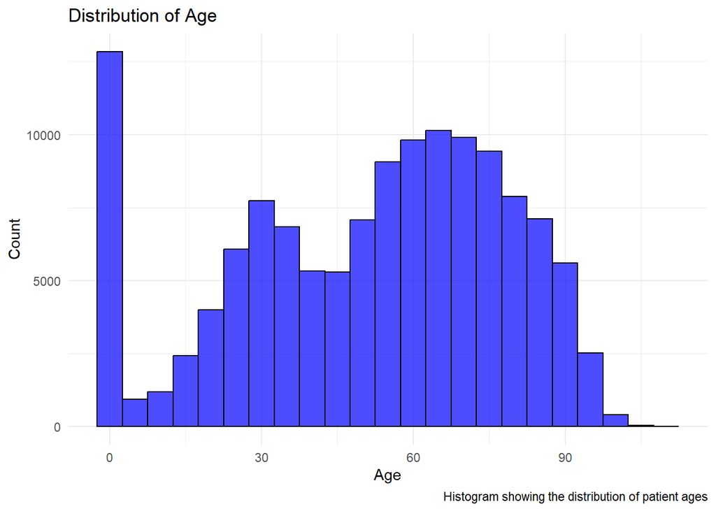

```r
# Example Plot 1: Distribution of Age
plot1 <- ggplot(df, aes(x = age)) +
  geom_histogram(binwidth = 5, fill = "blue", color = "black", alpha = 0.7) +
  labs(title = "Distribution of Age",
       x = "Age",
       y = "Count",
       caption = "Histogram showing the distribution of patient ages") +
  theme_minimal()
print(plot1)
```

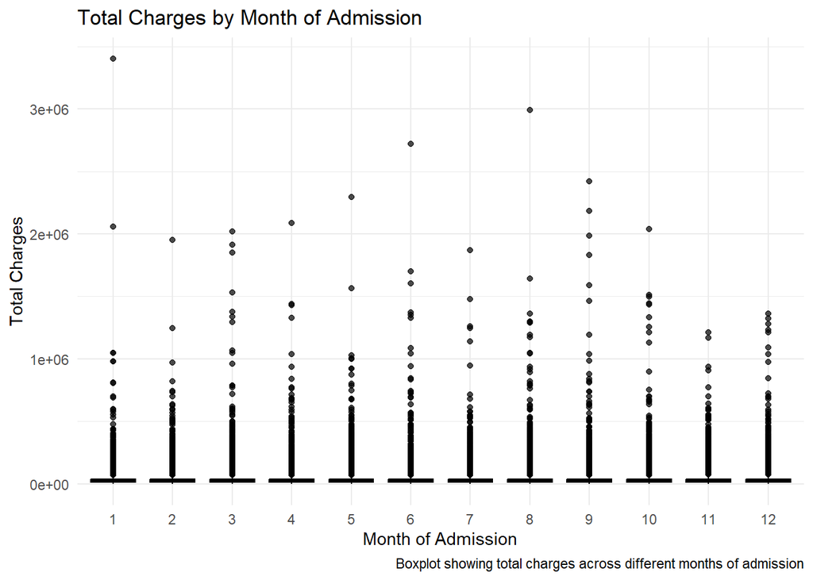

```r
# Example Plot 2: Total Charges by Month of Admission
plot2 <- ggplot(df, aes(x = factor(moa), y = tot)) +
  geom_boxplot(fill = "orange", color = "black", alpha = 0.7) +
  labs(title = "Total Charges by Month of Admission",
       x = "Month of Admission",
       y = "Total Charges",
       caption = "Boxplot showing total charges across different months of admission") +
  theme_minimal()
print(plot2)
```

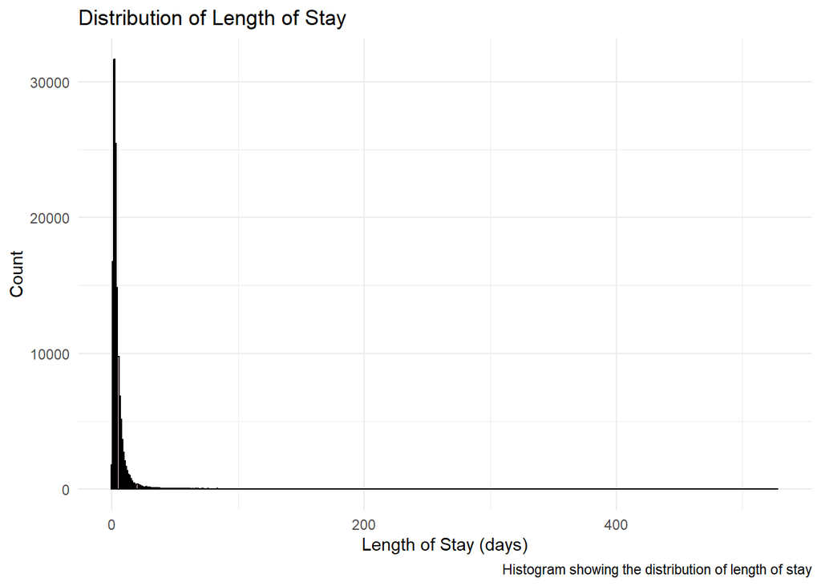

```r
# Example Plot 3: Distribution of Length of Stay
plot3 <- ggplot(df, aes(x = los)) +
  geom_histogram(binwidth = 1, fill = "pink", color = "black", alpha = 0.7) +
  labs(title = "Distribution of Length of Stay",
       x = "Length of Stay (days)",
       y = "Count",
       caption = "Histogram showing the distribution of length of stay") +
  theme_minimal()
print(plot3)
```

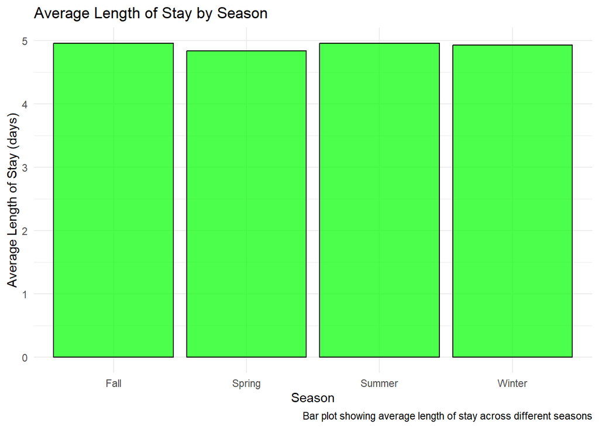

```r
# Example Plot 4: Average Length of Stay by Season
plot4 <- ggplot(df, aes(x = factor(season), y = los)) +
  geom_bar(stat = "summary", fun = "mean", fill = "green", color = "black", alpha = 0.7) +
  labs(title = "Average Length of Stay by Season",
       x = "Season",
       y = "Average Length of Stay (days)",
       caption = "Bar plot showing average length of stay across different seasons") +
  theme_minimal()
print(plot4)
```

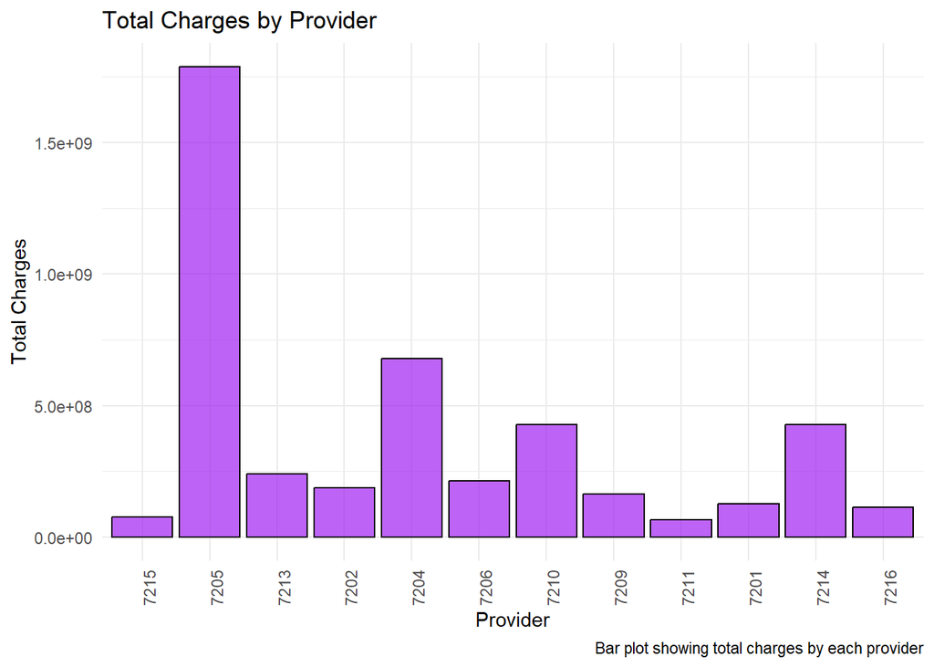

```r
# Example Plot 5: Total Charges by Provider
plot5 <- ggplot(df, aes(x = reorder(provider, -tot), y = tot)) +
  geom_bar(stat = "summary", fun = "sum", fill = "purple", color = "black", alpha = 0.7) +
  labs(title = "Total Charges by Provider",
       x = "Provider",
       y = "Total Charges",
       caption = "Bar plot showing total charges by each provider") +
  theme_minimal() +
  theme(axis.text.x = element_text(angle = 90, hjust = 1))
print(plot5)
```

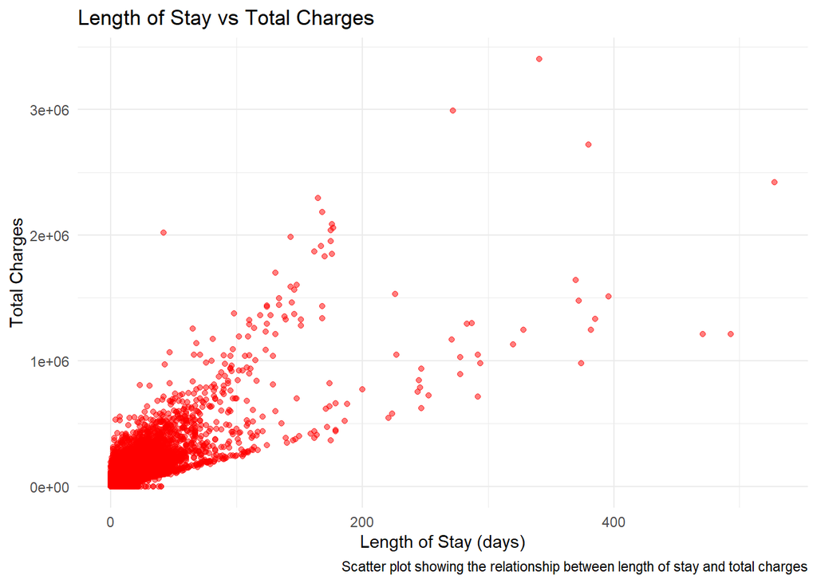

```r
# Example Plot 6: Length of Stay vs Total Charges
plot6 <- ggplot(df, aes(x = los, y = tot)) +
  geom_point(alpha = 0.5, color = "red") +
  labs(title = "Length of Stay vs Total Charges",
       x = "Length of Stay (days)",
       y = "Total Charges",
       caption = "Scatter plot showing the relationship between length of stay and total charges") +
  theme_minimal()
print(plot6)
```

```r
# Example Plot 7: Average Total Charges by Age Group
plot7 <- ggplot(df, aes(x = cut(age, breaks = seq(0, 100, by = 10)), y = tot)) +
  geom_bar(stat = "summary", fun = "mean", fill = "cyan", color = "black", alpha = 0.7) +
  labs(title = "Average Total Charges by Age Group",
       x = "Age Group",
       y = "Average Total Charges",
       caption = "Bar plot showing average total charges across different age groups") +
  theme_minimal()
print(plot)
```

[output not shown]

[output not shown]

[output not shown]

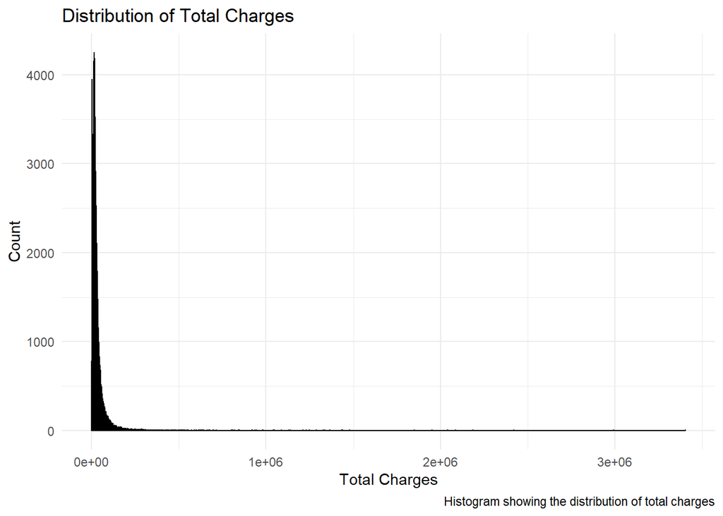

```r
## Example Plot 8: Distribution of Total Charges
plot8 <- ggplot(df, aes(x = tot)) +
  geom_histogram(binwidth = 1000, fill = "yellow", color = "black", alpha = 0.7) +
  labs(title = "Distribution of Total Charges",
       x = "Total Charges",
       y = "Count",
       caption = "Histogram showing the distribution of total charges") +
  theme_minimal()
print(plot8)
```

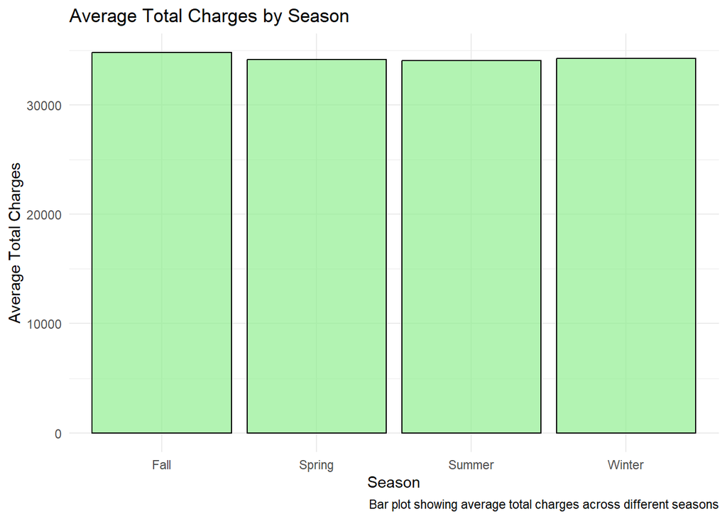

```r
## Example Plot 9: Average Total Charges by Season
plot9 <- ggplot(df, aes(x = factor(season), y = tot)) +
  geom_bar(stat = "summary", fun = "mean", fill = "lightgreen", color = "black", alpha = 0.7) +
  labs(title = "Average Total Charges by Season",
       x = "Season",
       y = "Average Total Charges",
       caption = "Bar plot showing average total charges across different seasons") +
  theme_minimal()
print(plot9)
```

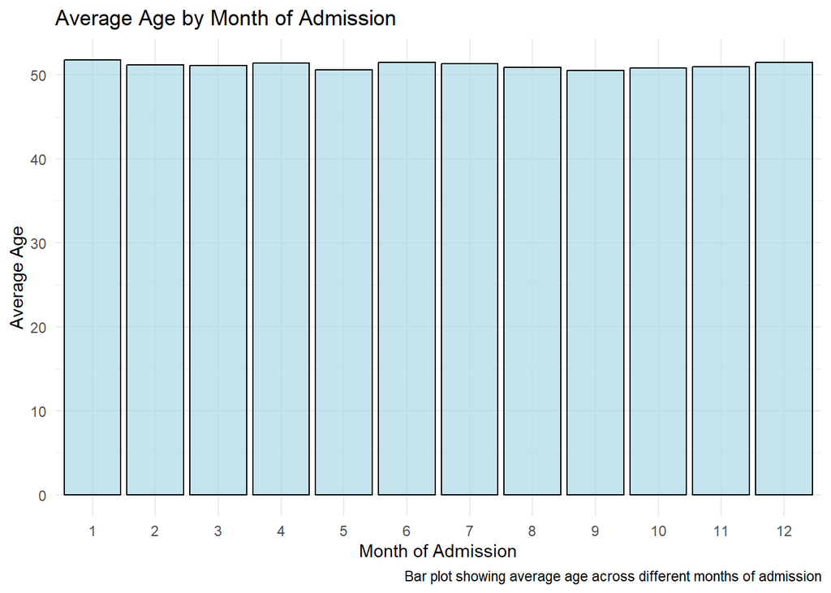

```r
## Example Plot 10: Average Age by Month of Admission
plot10 <- ggplot(df, aes(x = factor(moa), y = age)) +
  geom_bar(stat = "summary", fun = "mean", fill = "lightblue", color = "black", alpha = 0.7) +
  labs(title = "Average Age by Month of Admission",
       x = "Month of Admission",
       y = "Average Age",
       caption = "Bar plot showing average age across different months of admission") +
  theme_minimal()
print(plot10)
```

2. Make an animation plot.

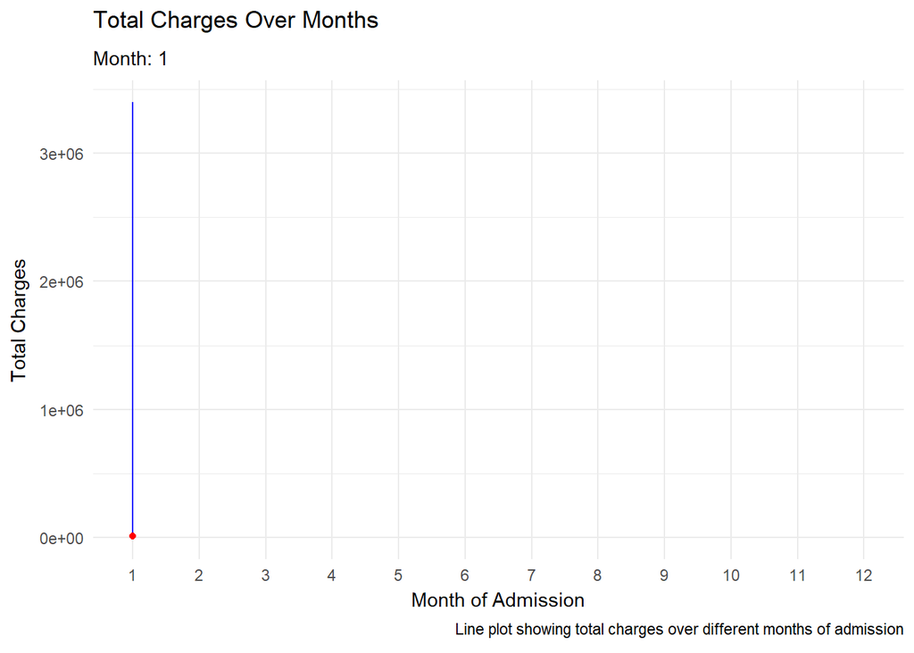

```r
## Example Animated Plot: Total Charges Over Months
plot11 <- ggplot(df, aes(x = factor(moa), y = tot, group = 1)) +
  geom_line(color = "blue") +
  geom_point(color = "red") +
  labs(title = "Total Charges Over Months",
       subtitle = "Month: {frame_along}",
       x = "Month of Admission",
       y = "Total Charges",
       caption = "Line plot showing total charges over different months of admission") +
  theme_minimal() +
  transition_reveal(moa)
animate(plot11, nframes = 100, fps = 10)
```

3. Write a paragraph to summarize the section and give your comments on the results. ## Summary Paragraph In this section, we created various visualizations to better understand the data from the Rhode Island Department of Health Hospital Discharge Data. The histograms and bar plots provided insights into the distribution of patient ages, total charges, and lengths of stay. For instance, we observed that the distribution of total charges is right-skewed, indicating that while most patients incur moderate charges, a few patients have significantly higher costs. The average length of stay varied by season, with summer showing the longest stays on average. Additionally, we explored relationships between variables, such as length of stay versus total charges, which revealed a positive correlation. The animated plot illustrated how total charges fluctuated over the months, providing a dynamic view of the data. Overall, these visualizations helped identify trends and patterns that may inform healthcare policy and resource allocation. ——-

## III. Predictive Models

Continue with the data from part I. Make sure you do not have any missing values in the data. Use the follows as the target and input variables:

*Target Variable*: Create the target variable taking value of

- `low` if the total charge of a patient (`tot`) is smaller than the median of the total charge, and
- `high` otherwise.

*Input Variables*:

- “age”,“sex”,“raceethn”,“provider”,“moa”,“mod”,“admtype”,“campus”, ‘los’
1. Use `filter` function to filter out rows where `raceethn==''` or `admtype==''`. Make sure all the categorical variables are factor, numeric variables are numeric. Set Training : Testing Split = 10 : 90

```r
library(dplyr)
df2 = read_sas('hdd0318cy.sas7bdat')
df2 <- df2 %>%
  filter(yod == 18)
df2 <- df2 %>%
  select("yod", "payfix","pay_ub92","age",
                      "sex","raceethn","provider","moa",
                      "yoa","mod","admtype", "asource" ,
                      "preopday" ,"los", "service" , "icu","ccu",
                      "dispub92", "payer"  ,"drg","trandb",
                      "randbg","randbs","orr", "anes","seq",
                      "lab","dtest", "ther","blood","phar",
                      "other","patcon","bwght","total","tot" ,
                      "ecodub92","b_wt","pt_state","diag_adm","ancilar" ,
                      "campus","er_fee","er_chrg","er_mode","obs_chrg",
                      "obs_hour","psycchrg","nicu_day")
missing_values <- df2 %>%
    summarise_all(~ sum(is.na(.)))
df <- df %>%
  select_if(~ !any(is.na(.)))
df2$total <- as.numeric(as.character(df2$total))
df2 <- df2 %>%
  filter(!is.na(raceethn) & !is.na(admtype))
df2 <- df2 %>%
  mutate(target = ifelse(total < median(total, na.rm = TRUE), "low", "high"))
table(df2$target)
```

```
##
##  high   low
## 65743 65735
```

```r
df2 <- df2 %>%
  select(age, sex, raceethn, provider, moa, mod, admtype, campus, los, target)
## Convert categorical variables to factors
library(caret)
df2 <- df2 %>%
  mutate(target = as.factor(target),
         raceethn = as.factor(raceethn),
         sex = as.factor(sex),
         provider = as.factor(provider),
         campus = as.factor(campus),
         admtype = as.factor(admtype),
         moa = as.factor(moa),
         mod = as.factor(mod))
## Set Training : Testing Split = 10 : 90
SplitIndex <- createDataPartition(df2$target, p = .10,
                                  list = FALSE)
df2_train <- df2[ SplitIndex, ]
df2_test  <- df2[-SplitIndex, ]
df2_train <- df2_train[ complete.cases(df2_train), ]
df2_test  <- df2_test[ complete.cases(df2_test), ]
stopifnot(sum(is.na(df2_train)) == 0)
stopifnot(sum(is.na(df2_test))  == 0)
```

2. Train a decision tree using `rpart`. Plot the decision tree. Plot the variable importance ranked by the tree.

```r
library(rpart)
```

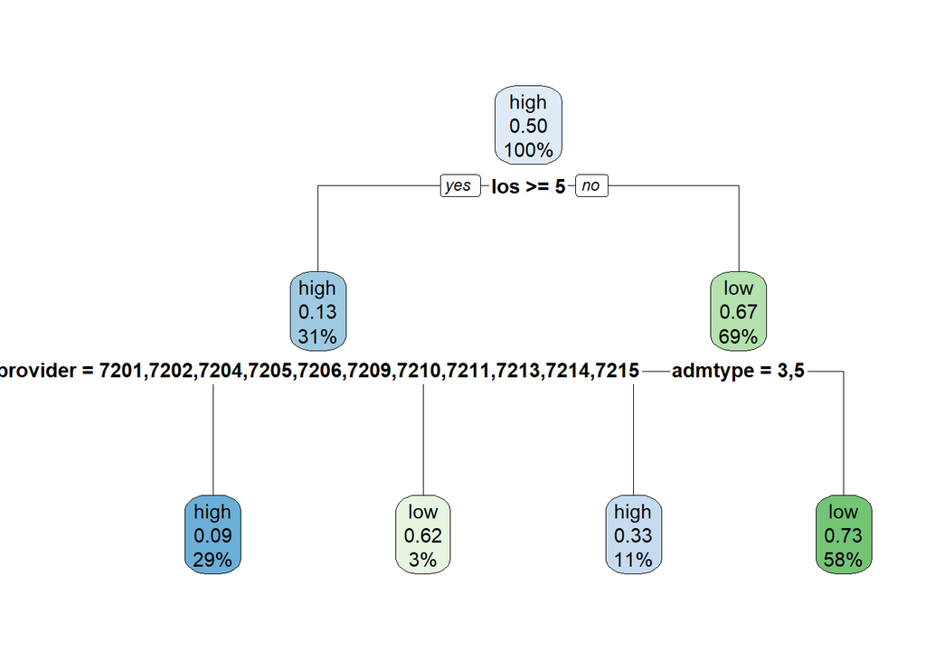

```r
library(rpart.plot)
library(caret)
## Model 1.1
dt_model <- rpart(target ~ .,
            data = df2_train,
            control=rpart.control(maxdepth=2))
rpart.plot(dt_model)
```

```r
if (!is.null(dt_model$splits) && nrow(dt_model$splits) > 0) {
  varImp <- varImp(dt_model)
  print(varImp)
} else {
  cat("Tree has no splits — variable importance not available.\n")
}
```

```
##            Overall
## admtype   879.9399
## age      1073.2049
## campus    565.2910
## los      1908.7871
## provider 1067.8708
## sex         0.0000
## raceethn    0.0000
## moa         0.0000
## mod         0.0000
```

3. Using caret for this question. Set `Training Control` to be: Use Cross-Validation of 5 folds across all models. Train & tune at least 2 different models (i.e. two different values for `method=` in the train function of caret). Plot the hyper-parameter tuning plots for each model.

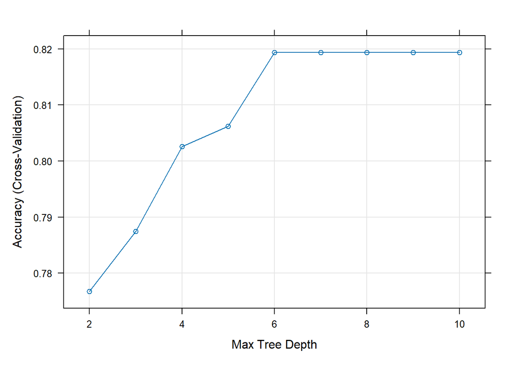

```r
library(caret)
## Model 1.2
tuneGrid <- expand.grid(maxdepth = 2:10)
trControl <- trainControl(method = "cv",
                         number = 5)
dt_model2 <- train(
  target ~ .,
  data = df2_train,
  method = "rpart2",
  trControl = trControl,
  tuneGrid = tuneGrid,
  na.action = na.omit
)
plot(dt_model2)
```

```r
## Model 1.3
knn_model <- train(
  target ~ .,
  data = df2_train,
  method = "knn",
  trControl = trControl,
  tuneLength = 10,
  na.action = na.omit
)
knn_model
```

```
## k-Nearest Neighbors
##
## 13149 samples
##     9 predictor
##     2 classes: 'high', 'low'
##
## No pre-processing
## Resampling: Cross-Validated (5 fold)
## Summary of sample sizes: 10519, 10519, 10519, 10519, 10520
## Resampling results across tuning parameters:
##
##   k   Accuracy   Kappa
##    5  0.7964097  0.5928222
##    7  0.7999841  0.5999713
##    9  0.8037106  0.6074245
##   11  0.8051555  0.6103141
##   13  0.8083500  0.6167034
##   15  0.8068287  0.6136606
##   17  0.8079696  0.6159425
##   19  0.8083500  0.6167034
##   21  0.8069047  0.6138127
##   23  0.8071330  0.6142695
##
## Accuracy was used to select the optimal model using the largest value.
## The final value used for the model was k = 19.
```

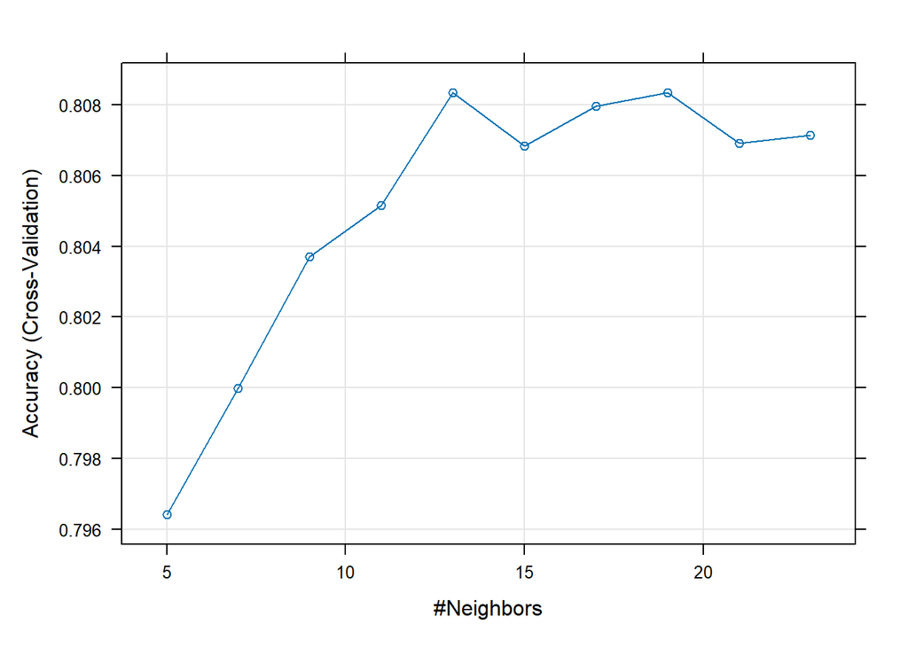

```r
plot(knn_model)
```

4. Plot the comparison of the models in 3.

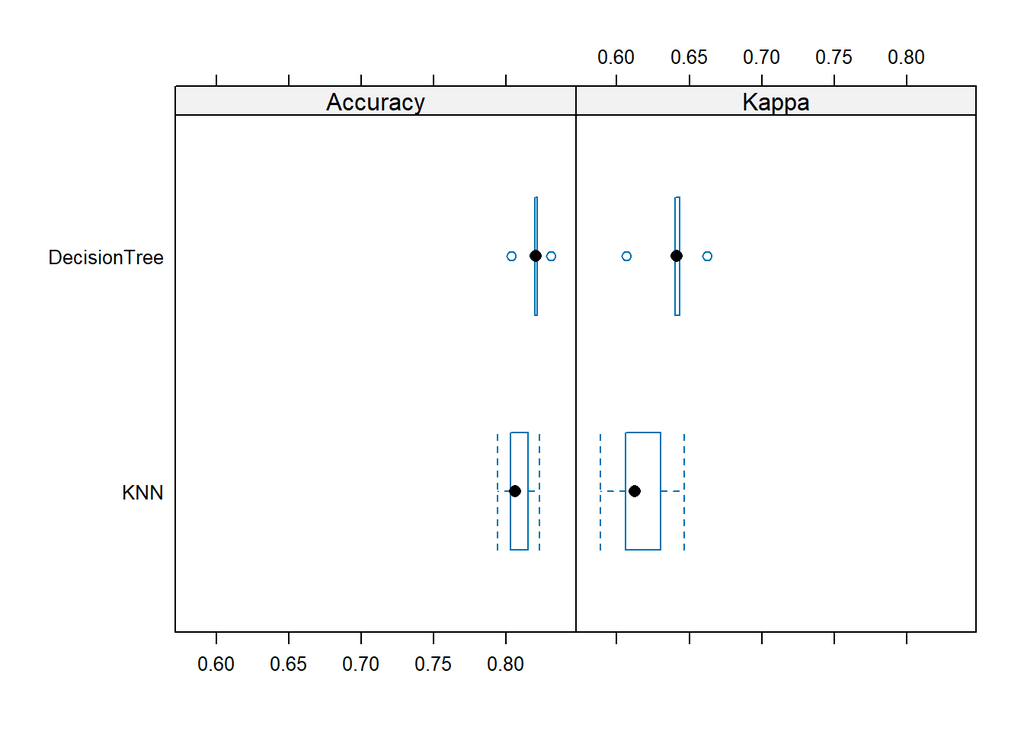

```r
results <- resamples(list(DecisionTree = dt_model2, KNN = knn_model))
bwplot(results)
```

5. What is your final selection for the model? Test the accuracy of your final model on the test data.

```r
## The final selection is the 5-fold rpart2 model
library(caret)
prediction <-predict(dt_model2, newdata = df2_test)
confusionmatrix <-confusionMatrix(data = prediction, reference = df2_test$target, positive = "high")
confusionmatrix$overall[1]
```

```
##  Accuracy
## 0.8157848
```

6. Create another `target` variable (binary), decide the input variables and redo 1 to 5.

```r
library(dplyr)
df3 = read_sas('hdd0318cy.sas7bdat')
df3 <- df3 %>%
  filter(yod == 18)
df3 <- df3 %>%
  select("yod", "payfix","pay_ub92","age",
                      "sex","raceethn","provider","moa",
                      "yoa","mod","admtype", "asource" ,
                      "preopday" ,"los", "service" , "icu","ccu",
                      "dispub92", "payer"  ,"drg","trandb",
                      "randbg","randbs","orr", "anes","seq",
                      "lab","dtest", "ther","blood","phar",
                      "other","patcon","bwght","total","tot" ,
                      "ecodub92","b_wt","pt_state","diag_adm","ancilar" ,
                      "campus","er_fee","er_chrg","er_mode","obs_chrg",
                      "obs_hour","psycchrg","nicu_day")
missing_values <- df3 %>%
    summarise_all(~ sum(is.na(.)))
df3$total <- as.numeric(as.character(df3$total))
df3 <- df3 %>%
  filter(!is.na(raceethn) & !is.na(admtype))
df3 <- df3 %>%
  mutate(target = case_when(
    sex == 1 ~ "Male",
    sex == 2 ~ "Female",
    TRUE     ~ NA_character_
  ))
df3 <- df3 %>%
  filter(!is.na(target))
table(df3$target, useNA = "ifany")
```

```
##
## Female   Male
##  72675  58799
```

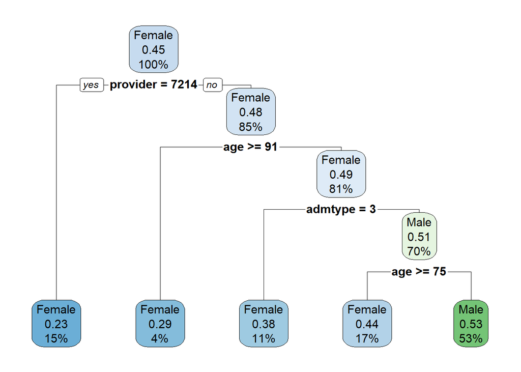

```r
df3 <- df3 %>%
  select(age, raceethn, provider, moa, mod, admtype, campus, total, los, target)
library(tidyverse)
library(caret)
library(rpart)
df3 <- df3 %>%
  mutate(target = as.factor(target),
         raceethn = as.factor(raceethn),
         age = as.numeric(age),
         provider = as.factor(provider),
         campus = as.factor(campus),
         admtype = as.factor(admtype),
         moa = as.factor(moa),
         mod = as.factor(mod),
         total = as.numeric(total))
splitIndex <- createDataPartition(df3$target, p = .10,
                                  list = FALSE)
df3_train <- df3[ splitIndex,]
df3_test <- df3[-splitIndex,]
## Model 2.1
dt_model2 <- rpart(target ~ .,
            data = df3_train,
            control=rpart.control(maxdepth=4))
library(rpart.plot)
library(caret)
rpart.plot(dt_model2)
```

```r
## Variable Importance
varImp2 <- varImp(dt_model2)
varImp2
```

```
##             Overall
## admtype  212.719509
## age      162.021194
## campus    64.969972
## moa        6.778988
## mod       16.939213
## provider 246.841738
## total     33.480551
## raceethn   0.000000
## los        0.000000
```

```r
if (!is.null(dt_model2$splits) && nrow(dt_model2$splits) > 0) {
  varImp2 <- varImp(dt_model2)
  print(varImp2)
} else {
  cat("Tree has no splits — variable importance not available.\n")
}
```

```
##             Overall
## admtype  212.719509
## age      162.021194
## campus    64.969972
## moa        6.778988
## mod       16.939213
## provider 246.841738
## total     33.480551
## raceethn   0.000000
## los        0.000000
```

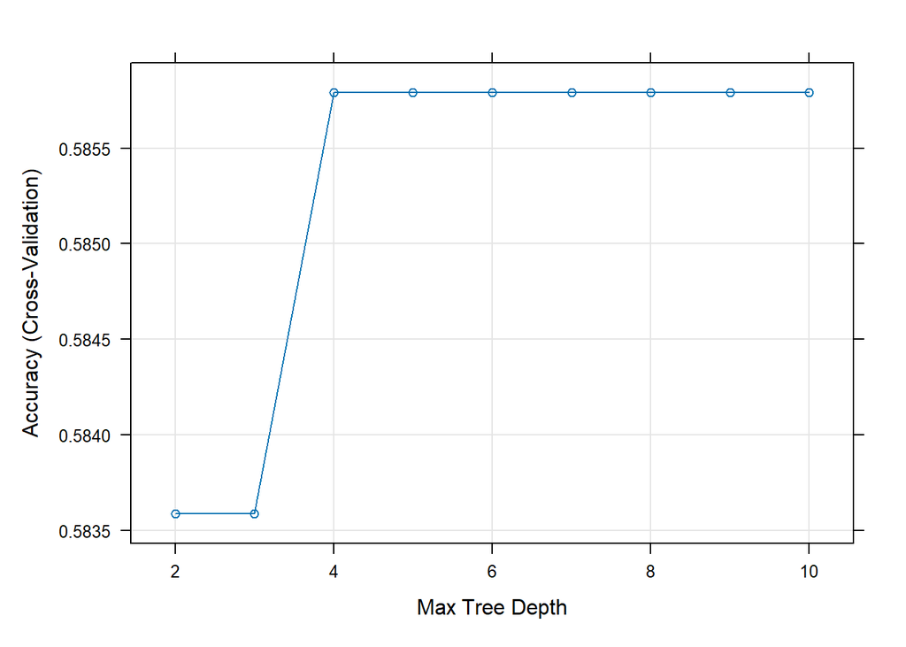

```r
## Model 2.2
tuneGrid2 <- expand.grid(maxdepth = 2:10)
trControl2 <- trainControl(method = "cv",
                         number = 5)
dt_model3 <- train(target~., data=df3_train,
                                method = "rpart2",
                                trControl = trControl2,
                                tuneGrid = tuneGrid2)
plot(dt_model3)
```

```r
## Model 2.3
knn_model2 <- train(
  target ~ .,
  data = df3_train,
  method = "knn",
  trControl = trControl2,
  tuneLength = 10
)
knn_model2
```

```
## k-Nearest Neighbors
##
## 13148 samples
##     9 predictor
##     2 classes: 'Female', 'Male'
##
## No pre-processing
## Resampling: Cross-Validated (5 fold)
## Summary of sample sizes: 10519, 10518, 10518, 10519, 10518
## Resampling results across tuning parameters:
##
##   k   Accuracy   Kappa
##    5  0.5386382  0.05971840
##    7  0.5361283  0.05300651
##    9  0.5327822  0.04400095
##   11  0.5276094  0.03093732
##   13  0.5305755  0.03510070
##   15  0.5288268  0.02894159
##   17  0.5305763  0.02928955
##   19  0.5279898  0.02286565
##   21  0.5302717  0.02450600
##   23  0.5343027  0.03227754
##
## Accuracy was used to select the optimal model using the largest value.
## The final value used for the model was k = 5.
```

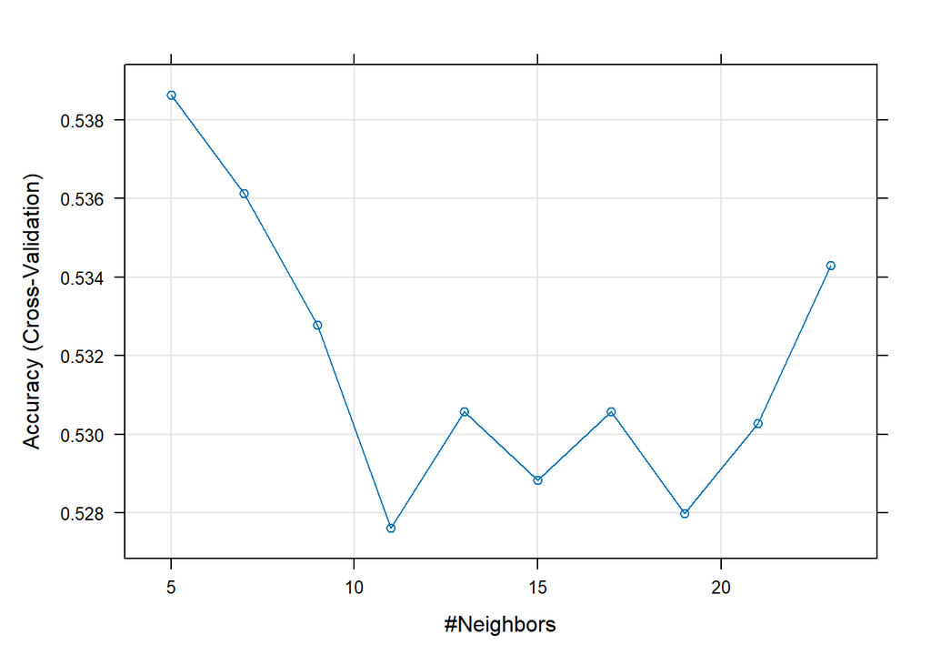

```r
plot(knn_model2)
```

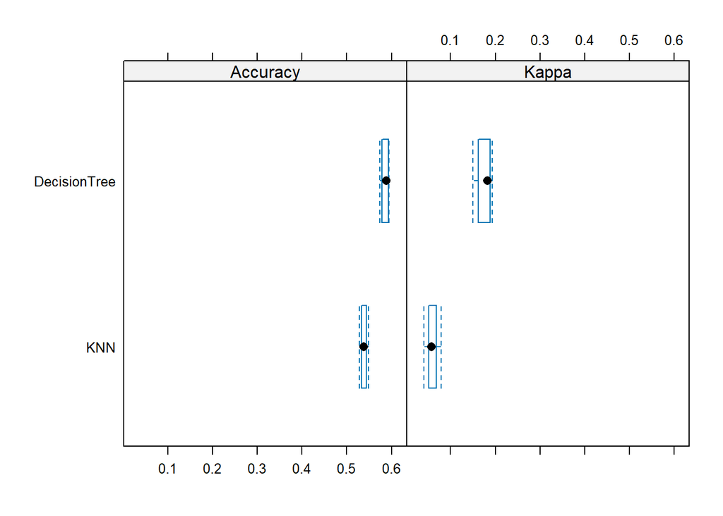

```r
## Model Comparison
results2 <- resamples(list(DecisionTree = dt_model3, KNN = knn_model2))
bwplot(results2)
```

```r
## Final Model Selection and Testing
prediction2 <-predict(dt_model3, newdata = df3_test)
confusionmatrix2 <- confusionMatrix(data = prediction2, reference = df3_test$target, positive = "Male")
confusionmatrix2$overall[1]
```

```
##  Accuracy
## 0.5858814
```